# One density surface, two kinds of data

A joint spatial model for marine mammal eDNA and visual line-transect surveys

Eiren Jacobson and the MMARINeDNA team

SMM 2026

## Two ways to count whales

|  | Visual line transects | eDNA |
| --- | --- | --- |
| **What is recorded** | Groups seen, their size and distance from the line | DNA copies in a filtered water sample |
| **What it tells us about density** | Absolute: animals per km², after correcting for detection | Relative: copies depend on shedding, decay and transport |
| **Where it works** | Daylight, calm seas, animals at the surface | Any weather; samples at depth; species that are hard to see |
| **Where it struggles** | Rare or cryptic species, rough seas | Turning copies into animals |

## Project goals

- **One density surface per species**, informed by both data streams at once
- **Calibrate eDNA against animals:** let visual data set the scale that links DNA copies to density
- **Fill gaps:** eDNA where there is little visual effort, or for species rarely seen
- **Honest uncertainty:** each data source keeps its own observation model
- **Test on simulations first**, where the truth is known

# The data

## Two surveys, one coast

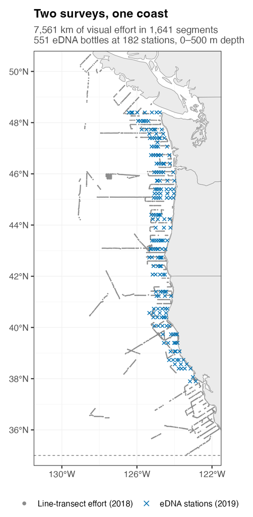

**Visual line transects** (2018 CCES)

- 7,561 km of effort in 1,641 segments
- Perpendicular distances, group sizes, Beaufort sea state

**eDNA** (2019)

- 551 water bottles, 0–500 m depth
- **qPCR** for Pacific hake
- **Metabarcoding** (MarVer1) for all vertebrates

**Study area:** north of 35°N, a 690 × 1,770 km box

## Humpback whale: easy to see, rare in eDNA

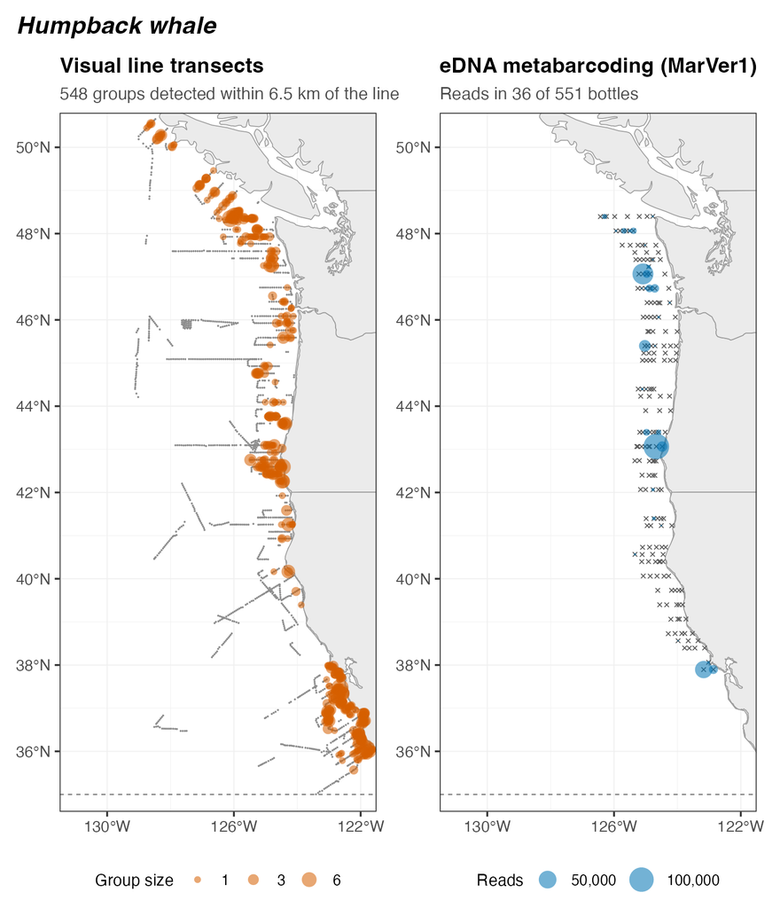

- 548 groups detected within 6.5 km of the line
- Reads in 36 of 551 bottles
- Visual data are rich; eDNA hits are sparse but broadly match the sighting hot spots

## Pacific white-sided dolphin: weak in both

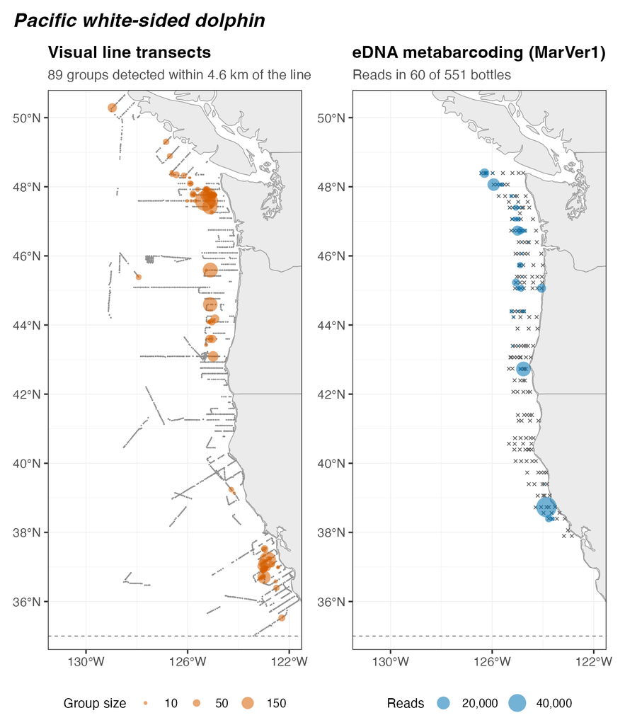

- 89 groups detected within 4.6 km of the line
- Reads in 60 of 551 bottles
- Few sightings, but large groups (up to hundreds)
- This is where combining sources should help most

## Pacific hake: the eDNA anchor

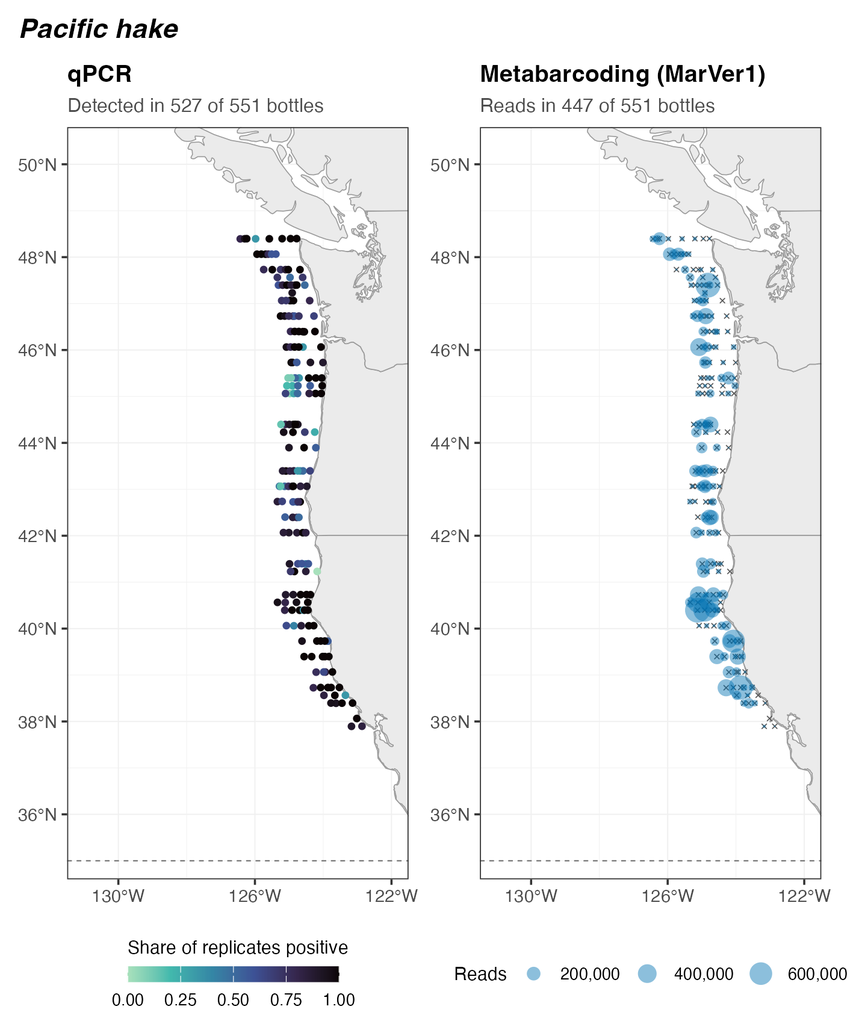

- qPCR detects hake in 527 of 551 bottles
- Metabarcoding reads in 447 bottles
- Not surveyed visually
- Abundant and eDNA-rich, so it pins down the **shared eDNA noise terms** (bottle-to-bottle variation, non-target DNA)

# The model

## The core idea: one latent field per species

$$\log \lambda_s(\mathbf{x}) \;=\; \underbrace{\mu_s}_{\text{intercept}} \;+\; \underbrace{f_s(X, Y)}_{\text{spatial GP}} \;+\; \underbrace{h_s(Z_\text{bottom})}_{\text{depth spline}}
\qquad \text{animals per km}^2$$

**eDNA**: expected copies in bottle $i$

$$\mu_{is} = \lambda_s(\mathbf{x}_i)\times c_s \times v_i \times \omega_s(z_i)$$

conversion factor $c_s$, litres filtered $v_i$, water-column offset $\omega_s$

**Visual**: expected groups on segment $j$

$$\mathbb{E}[n_j] = \frac{\lambda_s(\mathbf{x}_j)}{\mathbb{E}[\text{group size}_s]}\times 2L_j \times \text{ESW}_{j}$$

segment length $L_j$, effective strip half-width $\text{ESW}_j$

## The latent field: a Hilbert-space Gaussian process

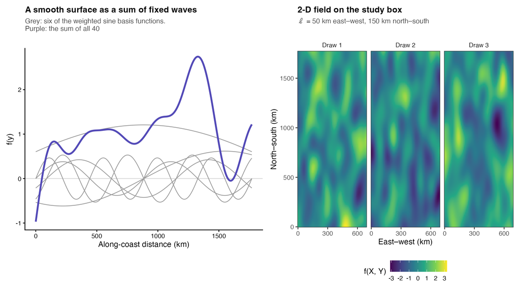

- **Anisotropic GP:** separate length-scales east–west and along the coast
- **HSGP approximation:** the GP is a weighted sum of fixed sine waves (up to 800), so the sampler fits hundreds of weights instead of an $N \times N$ covariance
- **Bottom depth:** smooth spline, 4 df
- **Priors from the survey design only:** sample spacing, domain size and basis budget, never the counts
- Fitted in **Stan**

## eDNA observation model

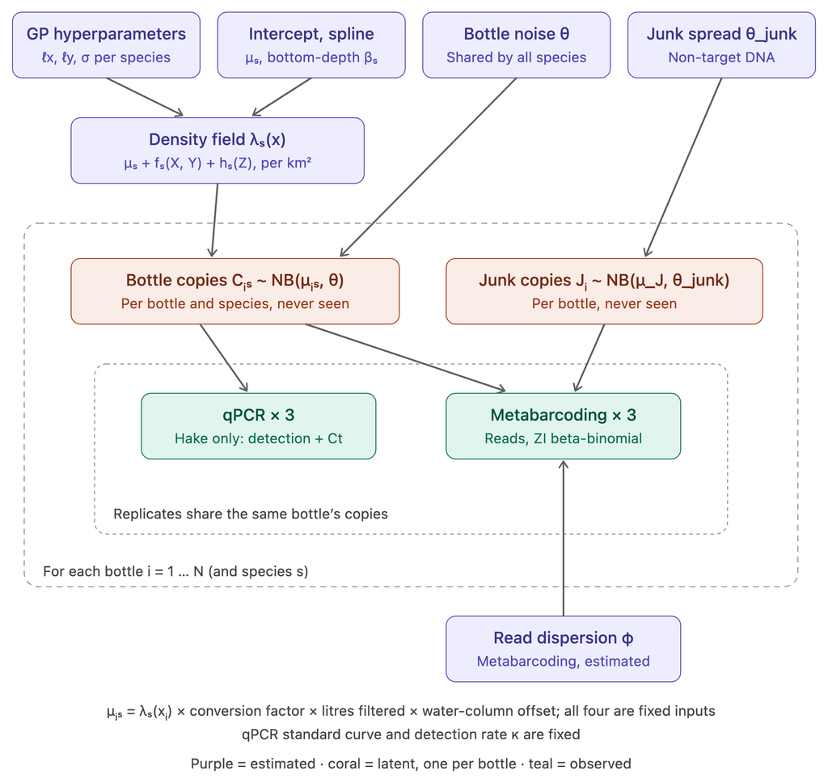

- **Bottle copies** $C_{is} \sim \text{NB}(\mu_{is}, \theta)$: bottles vary even at the same density
- **Non-target “junk” DNA** $J_i$, with its own spread $\theta_\text{junk}$
- **qPCR** (hake): detection with probability $1 - e^{-\kappa C}$; Ct falls linearly with $\ln C$
- **Metabarcoding**: reads split among species and junk in proportion to copies; zero-inflated beta-binomial
- Replicates share their bottle’s copies

## Visual observation model

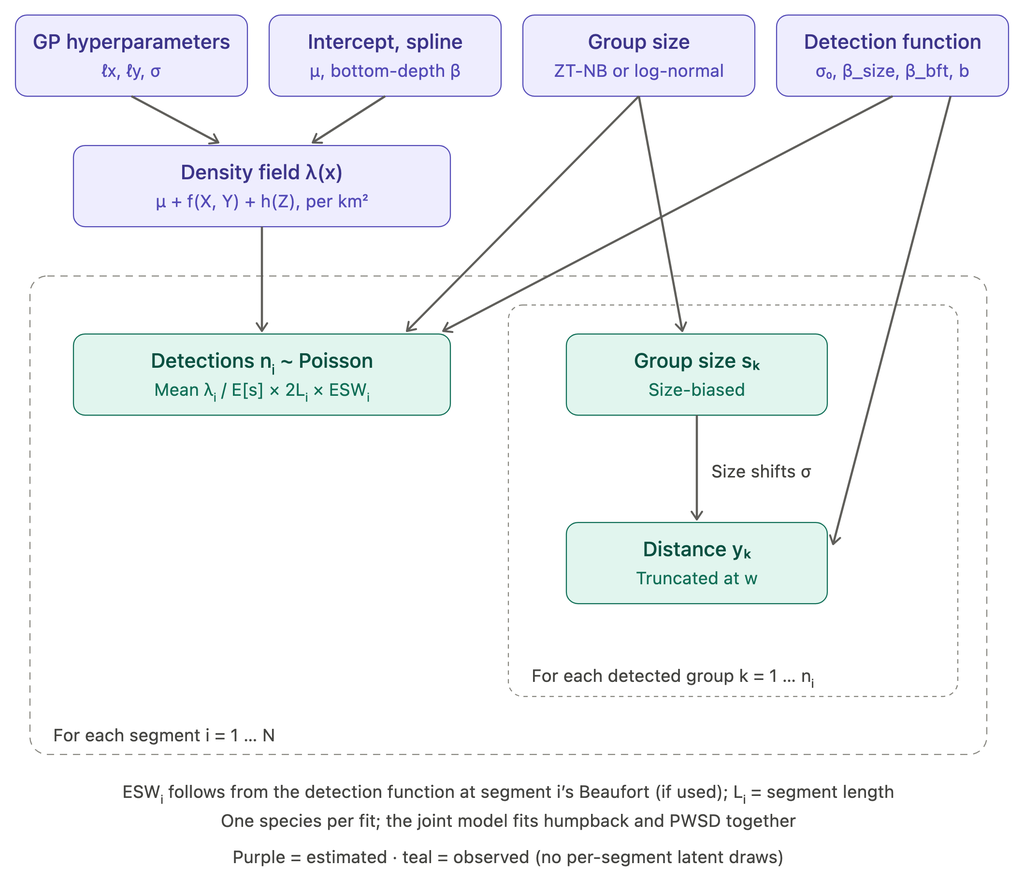

- **Encounters:** groups per segment are Poisson with mean $\lambda / \mathbb{E}[s] \times 2L \times \text{ESW}$
- **Distances:** half-normal or hazard-rate detection, truncated at $w$; $\log\sigma = \log\sigma_0 + \beta_\text{size}(s-\bar s) + \beta_\text{bft}(\text{Bft}-3)$
- **Group size:** modelled, with size-bias correction
- Same field, units and priors as the eDNA side
- $g(0) = 1$ assumed (for now)

## The joint model

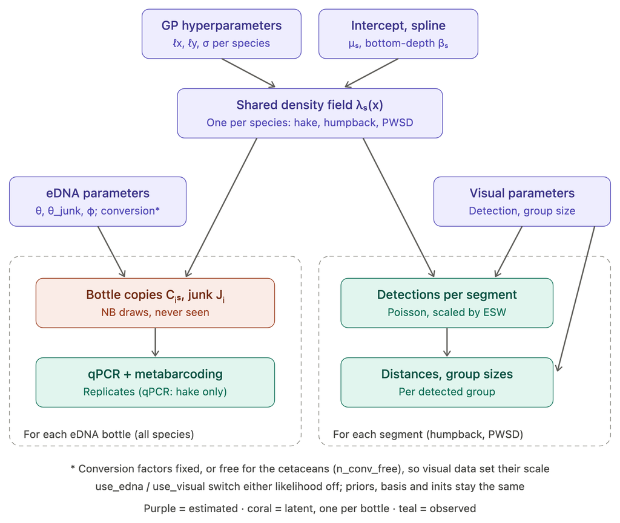

- **One field per species** feeds both observation models
- **Switches** turn either likelihood off: eDNA-only, visual-only and joint fits share priors, basis and starting values, and differ only in data
- With one side switched off, it reproduces the single-source model exactly
- **Conversion factors** $c_s$ can be **estimated** for the cetaceans

## Why combining should help

- **eDNA alone** sees only $\lambda_s \times c_s$, so it can map *relative* density but cannot separate density from the conversion factor
- **Visual data** fix the absolute scale of $\lambda_s$, so the joint model can **estimate $c_s$**: copies per unit of animal density
- **eDNA** adds information where visual effort is thin or sightings are few, sharpening the surface
- **Shared noise terms**, learned mostly from hake, carry over to the rare whale signals

# Simulation study

## Simulation design

| Species | eDNA | Visual detections | Role |
| --- | --- | --- | --- |
| Pacific hake | qPCR + metabarcoding | not surveyed | eDNA-rich anchor |
| Humpback whale | metabarcoding | ~800–1,700 | rare in eDNA, conspicuous at the surface |
| Pacific white-sided dolphin | metabarcoding | ~100–150 | weak in both |

- Study box north of 35°N, 690 × 1,770 km
- 200 eDNA stations; 35 east–west transects in 10 km segments
- True length-scales: 50 km east–west, 150 km along the coast
- Four fits per dataset: **eDNA-only, visual-only, joint, joint with $c_s$ free**
- Scored on field $R^2$, 95% interval width and coverage, and recovery of $c_s$

## Results: one simulated dataset, four fits

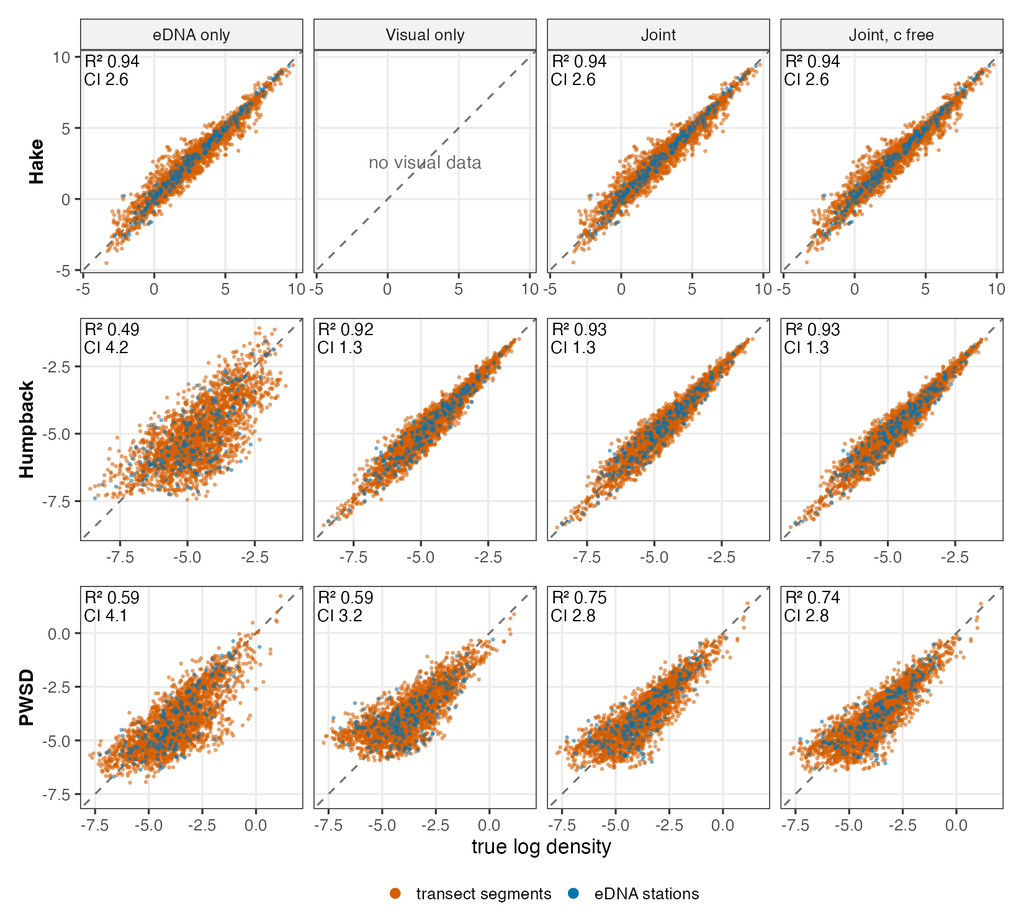

## Results: what the joint model adds

| Field $R^2$ (CI width) | eDNA only | Visual only | Joint | Joint, $c_s$ free |
| --- | --- | --- | --- | --- |
| Hake | 0.94 (2.6) | not surveyed | 0.94 (2.6) | 0.94 (2.6) |
| Humpback | 0.49 (4.2) | 0.92 (1.3) | **0.93 (1.3)** | 0.93 (1.3) |
| PWSD | 0.59 (4.1) | 0.59 (3.2) | **0.75 (2.8)** | 0.74 (2.8) |

- **$c_s$ recovered** (log scale): humpback 5.30 [5.05, 5.53], truth 5.30; PWSD 4.77 [4.45, 5.08], truth 4.70
- True field covered: 92–96% in every fit
- Converged: no divergences, $\hat{R} \le 1.06$ (eDNA-only 1.11, bottle noise)
- One dataset so far; replicates running

## Next steps

- **Replicates:** more simulated datasets (running now)
- **Real data:** fit the joint model to the 2018 sightings and 2019 eDNA
- **eDNA inputs:** qPCR Ct values and standard curves; volumes filtered
- **Detection:** Beaufort covariate in the joint model’s visual side; $g(0)$
- **Different years:** the surveys are a year apart, so the joint fit assumes a stable density surface
- **eDNA transport and decay:** where the DNA is is not quite where the animal is

## Thank you

https://github.com/MMARINeDNA/eDNAVisualJointModel